# Short HTML example of R Markdown

Garret Christensen

06 October, 2017

# ONE CLICK! Knit HTML and you’re done.

1. Remember how we had to set the directory in Stata? R Projects to the rescue! And it’s got version control built right in. Look under Tools>Version Control. (OMG someone build this for Stata plz.)

(If you’re doing filepaths by yourself in R, and you’re on a Windows machine and you copy-pasted the filepath, change slash directions. Ugh.)

2. Install/Load packages. You only have to install a package once, but you have to load the library every time you want to use it. You’ll see that a bunch of ugly commands and output gets displayed. You probably wouldn’t really want that in your actual paper.

```r
# Loading required libraries
list.of.packages <- c("foreign", "stargazer", "sandwich", "haven")

# Chicking if library installed, installed if not.
new.packages <- list.of.packages[!(list.of.packages %in% installed.packages()[,"Package"])]
if(length(new.packages)) install.packages(new.packages, repos= "http://cran.cnr.berkeley.edu/")

# Calling libraries
lapply(list.of.packages, require, character.only = TRUE)
```

```
## [[1]]
## [1] TRUE
##
## [[2]]
## [1] TRUE
##
## [[3]]
## [1] TRUE
##
## [[4]]
## [1] TRUE
```

Which is why you can turn off code (with echo=FALSE) and/or results (with results=‘hide’). You’re not going to see anything from this chunk here:

[output not shown]

## Loading the data

You can bring in the Stata data directly with the ‘foreign’ package.

## Running Analysis

I ran some regression analysis. The results are good.

# Graphics

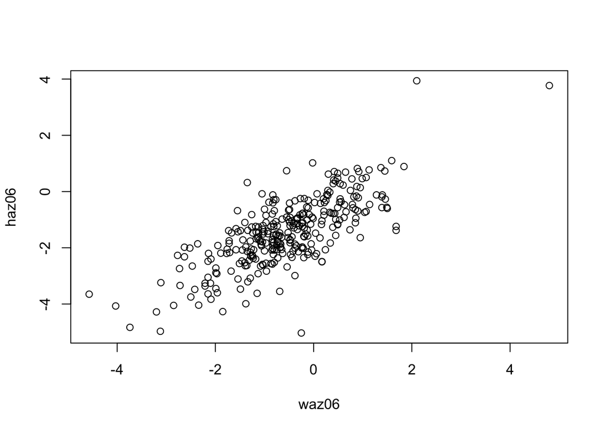

# Equations

Equations written with LaTeX syntax works, so you can write short reports all in one file.
$$\frac{dN}{dt} = r * N * (1 - \frac{N}{K})$$

# Refer to Values

You can refer to values calculated in R by just surrounding “r” and the code with single accent marks. For example, the mean frequency is 0.4822888.

# Simple Output

You can just use built in R functionality.

```
##
## Call:
## lm(formula = free_chl_yn ~ treatw, data = WASHB)
##
## Residuals:
##      Min       1Q   Median       3Q      Max
## -0.37692 -0.37692 -0.01299 -0.01299  0.98701
##
## Coefficients:
##             Estimate Std. Error t value Pr(>|t|)
## (Intercept)  0.01299    0.02736   0.475    0.635
## treatw       0.36394    0.04044   9.000   <2e-16 ***
## ---
## Signif. codes:  0 '***' 0.001 '**' 0.01 '*' 0.05 '.' 0.1 ' ' 1
##
## Residual standard error: 0.3395 on 282 degrees of freedom
##   (83 observations deleted due to missingness)
## Multiple R-squared:  0.2231, Adjusted R-squared:  0.2204
## F-statistic:    81 on 1 and 282 DF,  p-value: < 2.2e-16
```

```
##
## Call:
## lm(formula = free_chl_yn ~ treatw + kiswahili + english, data = WASHB)
##
## Residuals:
##      Min       1Q   Median       3Q      Max
## -0.39602 -0.35122 -0.02021  0.00334  0.97979
##
## Coefficients:
##              Estimate Std. Error t value Pr(>|t|)
## (Intercept) -0.003344   0.052899  -0.063    0.950
## treatw       0.365188   0.040614   8.992   <2e-16 ***
## kiswahili   -0.010624   0.075772  -0.140    0.889
## english      0.034176   0.063663   0.537    0.592
## ---
## Signif. codes:  0 '***' 0.001 '**' 0.01 '*' 0.05 '.' 0.1 ' ' 1
##
## Residual standard error: 0.3405 on 280 degrees of freedom
##   (83 observations deleted due to missingness)
## Multiple R-squared:  0.2243, Adjusted R-squared:  0.216
## F-statistic: 26.98 on 3 and 280 DF,  p-value: 2.33e-15
```

# Fancier Output

Markdown is designed to be simple and also readable by humans in marked-up form. Like I said, mark*down*, not mark*up*. But you can still get really nicely formatted regression output with a couple of R packages, xtable or stargazer. (Very similar to estout or outreg2 in Stata.)

Stargazer has three types of output (text, html, and LaTeX). This file does HTM. For the LaTeX(PDF) version see the file (RMarkdownPDFExample.Rmd). There are very few differences–you pretty much just have to tell stargazer what to expect with the ‘type’ option and you’re done.

## RMarkdown–>HTML

**Made Automatically in R**

|  | *Dependent variable:* |  |  |
| --- | --- | --- | --- |
|  | free_chl_yn |  |  |
|  | default | robust | controls |
|  | (1) | (2) | (3) |
| treatw | 0.364*** | 0.364*** | 0.365*** |
|  | (0.040) | (0.043) | (0.041) |
| kiswahili |  |  | -0.011 |
|  |  |  | (0.076) |
| english |  |  | 0.034 |
|  |  |  | (0.064) |
| Constant | 0.013 | 0.013 | -0.003 |
|  | (0.027) | (0.009) | (0.053) |
| Observations | 284 | 284 | 284 |
| R<sup>2</sup> | 0.223 | 0.223 | 0.224 |
| Adjusted R<sup>2</sup> | 0.220 | 0.220 | 0.216 |
| Residual Std. Error | 0.340 (df = 282) | 0.340 (df = 282) | 0.340 (df = 280) |
| F Statistic | 81.002*** (df = 1; 282) | 81.002*** (df = 1; 282) | 26.982*** (df = 3; 280) |
| *Note:* | p<0.1; p<0.05; p<0.01 |  |  |

# Everything All in One Place?

You can do [citations](http://rmarkdown.rstudio.com/authoring_bibliographies_and_citations.html). Plots, graphs, and citations, what else do you need for a research paper?

Knitr is smart! It doesn’t re-run code that hasn’t changed, meaning it can be fast. You don’t need to worry about re-running your whole paper every time you change a single line of code.

Knitr’s predecessor is called Sweave, which is a direct combo of LaTeX and R. So you might want to try that out if you’re already a LaTeX pro, but I’m pretty sure Knitr is better.

Send your output to .tex files, include those in your master paper file.